# Data_Mining_Clustering_Project_Tribid

```python
import pandas as pd
import numpy as np
import matplotlib.pyplot as plt
import seaborn as sns
from sklearn.cluster import KMeans
import warnings
warnings.filterwarnings("ignore")
from scipy.cluster.hierarchy import dendrogram, linkage

from sklearn.model_selection import train_test_split
from sklearn.preprocessing import StandardScaler
from sklearn.neural_network import MLPClassifier
from sklearn.tree import DecisionTreeClassifier
from sklearn.ensemble import RandomForestClassifier
from sklearn.metrics import confusion_matrix,classification_report,roc_auc_score,accuracy_score,roc_auc_score,roc_curve
```

```python
import os
os.chdir('C:\\Users\\tmaji\\Downloads')
os.getcwd()
```

```
'C:\\Users\\tmaji\\Downloads'
```

```python
df=pd.read_csv('bank_marketing_part1_Data.csv')
df.head()
```

|  | spending | advance_payments | probability_of_full_payment | current_balance | credit_limit | min_payment_amt | max_spent_in_single_shopping |
| --- | --- | --- | --- | --- | --- | --- | --- |
| 0 | 19.94 | 16.92 | 0.8752 | 6.675 | 3.763 | 3.252 | 6.550 |
| 1 | 15.99 | 14.89 | 0.9064 | 5.363 | 3.582 | 3.336 | 5.144 |
| 2 | 18.95 | 16.42 | 0.8829 | 6.248 | 3.755 | 3.368 | 6.148 |
| 3 | 10.83 | 12.96 | 0.8099 | 5.278 | 2.641 | 5.182 | 5.185 |
| 4 | 17.99 | 15.86 | 0.8992 | 5.890 | 3.694 | 2.068 | 5.837 |

```python
df.info()
```

```
<class 'pandas.core.frame.DataFrame'>
RangeIndex: 210 entries, 0 to 209
Data columns (total 7 columns):
 #   Column                        Non-Null Count  Dtype
---  ------                        --------------  -----
 0   spending                      210 non-null    float64
 1   advance_payments              210 non-null    float64
 2   probability_of_full_payment   210 non-null    float64
 3   current_balance               210 non-null    float64
 4   credit_limit                  210 non-null    float64
 5   min_payment_amt               210 non-null    float64
 6   max_spent_in_single_shopping  210 non-null    float64
dtypes: float64(7)
memory usage: 11.6 KB
```

```python
df.describe().T
```

|  | count | mean | std | min | 25% | 50% | 75% | max |
| --- | --- | --- | --- | --- | --- | --- | --- | --- |
| spending | 210.0 | 14.847524 | 2.909699 | 10.5900 | 12.27000 | 14.35500 | 17.305000 | 21.1800 |
| advance_payments | 210.0 | 14.559286 | 1.305959 | 12.4100 | 13.45000 | 14.32000 | 15.715000 | 17.2500 |
| probability_of_full_payment | 210.0 | 0.870999 | 0.023629 | 0.8081 | 0.85690 | 0.87345 | 0.887775 | 0.9183 |
| current_balance | 210.0 | 5.628533 | 0.443063 | 4.8990 | 5.26225 | 5.52350 | 5.979750 | 6.6750 |
| credit_limit | 210.0 | 3.258605 | 0.377714 | 2.6300 | 2.94400 | 3.23700 | 3.561750 | 4.0330 |
| min_payment_amt | 210.0 | 3.700201 | 1.503557 | 0.7651 | 2.56150 | 3.59900 | 4.768750 | 8.4560 |
| max_spent_in_single_shopping | 210.0 | 5.408071 | 0.491480 | 4.5190 | 5.04500 | 5.22300 | 5.877000 | 6.5500 |

```python
df.isnull().sum()
```

```
spending                        0
advance_payments                0
probability_of_full_payment     0
current_balance                 0
credit_limit                    0
min_payment_amt                 0
max_spent_in_single_shopping    0
dtype: int64
```

```python
df.shape
```

```
(210, 7)
```

```python
#Checking for Duplicates
dups = df.duplicated()
print('Number of duplicate rows = %d' % (dups.sum()))
```

```
Number of duplicate rows = 0
```

# Scaling the data

```python
from sklearn.preprocessing import StandardScaler
X = StandardScaler()
```

```python
scaled_clust = pd.DataFrame(X.fit_transform(df), columns=df.columns)
```

```python
scaled_clust.head()
```

|  | spending | advance_payments | probability_of_full_payment | current_balance | credit_limit | min_payment_amt | max_spent_in_single_shopping |
| --- | --- | --- | --- | --- | --- | --- | --- |
| 0 | 1.754355 | 1.811968 | 0.178230 | 2.367533 | 1.338579 | -0.298806 | 2.328998 |
| 1 | 0.393582 | 0.253840 | 1.501773 | -0.600744 | 0.858236 | -0.242805 | -0.538582 |
| 2 | 1.413300 | 1.428192 | 0.504874 | 1.401485 | 1.317348 | -0.221471 | 1.509107 |
| 3 | -1.384034 | -1.227533 | -2.591878 | -0.793049 | -1.639017 | 0.987884 | -0.454961 |
| 4 | 1.082581 | 0.998364 | 1.196340 | 0.591544 | 1.155464 | -1.088154 | 0.874813 |

# Creating Clusters using KMeans

```python
from sklearn.cluster import KMeans

k_means = KMeans(n_clusters = 2,random_state=1)
```

```python
k_means.fit(scaled_clust)
```

```
KMeans(n_clusters=2, random_state=1)
```

# Cluster Output for all the observations

```python
k_means.labels_
```

```
array([1, 0, 1, 0, 1, 0, 0, 0, 1, 0, 1, 0, 0, 1, 0, 0, 1, 0, 0, 0, 0, 0,
       1, 0, 0, 1, 0, 0, 0, 0, 0, 0, 0, 1, 0, 0, 0, 0, 0, 1, 1, 0, 1, 1,
       0, 0, 0, 1, 1, 1, 0, 1, 1, 1, 1, 1, 0, 0, 0, 1, 0, 0, 0, 0, 0, 1,
       1, 0, 1, 0, 0, 0, 1, 1, 0, 1, 0, 0, 1, 0, 0, 0, 0, 1, 0, 0, 1, 1,
       1, 0, 0, 1, 0, 0, 0, 1, 1, 1, 0, 1, 0, 1, 0, 1, 0, 1, 1, 0, 0, 1,
       1, 0, 1, 0, 0, 1, 0, 0, 0, 1, 0, 0, 0, 0, 0, 0, 1, 0, 0, 0, 0, 0,
       0, 1, 0, 1, 1, 0, 1, 0, 0, 0, 0, 0, 0, 0, 1, 0, 0, 0, 0, 0, 0, 1,
       0, 0, 0, 0, 0, 1, 1, 0, 1, 1, 1, 0, 1, 0, 0, 0, 1, 0, 0, 1, 1, 1,
       0, 0, 1, 0, 0, 0, 0, 0, 1, 1, 0, 0, 0, 0, 0, 0, 0, 1, 0, 1, 1, 0,
       1, 0, 0, 1, 0, 0, 1, 0, 1, 0, 1, 1])
```

# Calculating WSS for other values of K - Elbow Method

```python
wss =[]
```

```python
for i in range(1,11):
    KM = KMeans(n_clusters=i,random_state=1)
    KM.fit(scaled_clust)
    wss.append(KM.inertia_)
```

```python
wss
```

[output not shown]

```python
k_means = KMeans(n_clusters = 3,random_state=1)
k_means.fit(scaled_clust)
labels = k_means.labels_
```

```python
from sklearn.metrics import silhouette_samples, silhouette_score
silhouette_score(scaled_clust,labels,random_state=1)
```

```
0.40072705527512986
```

```python
k_means = KMeans(n_clusters = 4,random_state=1)
k_means.fit(scaled_clust)
labels = k_means.labels_
```

```python
silhouette_score(scaled_clust,labels,random_state=1)
```

```
0.32757426605518075
```

# 1.1 Read the data, do the necessary initial steps, and exploratory data analysis (Univariate, Bi-variate, and multivariate analysis).

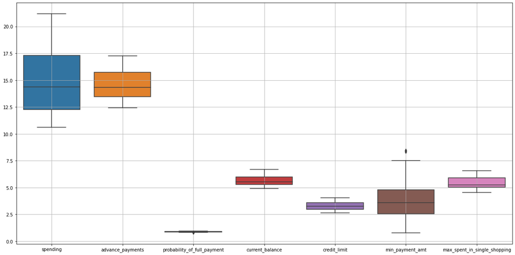

```python
#Univariate Analysis
plt.figure(figsize=(20,10))
sns.boxplot(data=df)
plt.grid()
plt.show()
```

```python
# The box plot of the variable shows no outliers:Spending,Advace Payment,Current Balance, Credit Limit,
# Max Spent in sigle shopping
#The box plot of the variable show outliers :Min Payment amount & Probabilty of full payment
```

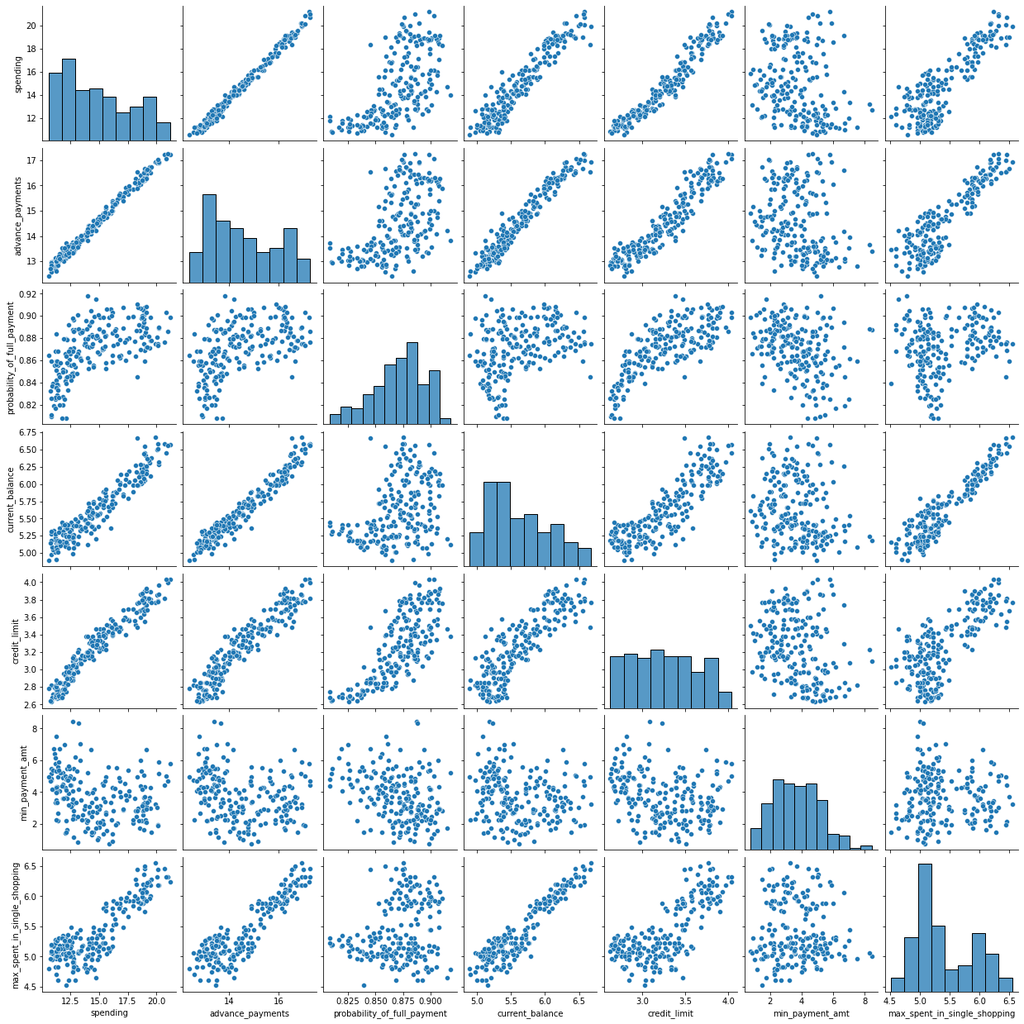

```python
#Mulit-variate Analysis
#pair-Plot
sns.pairplot(df)
```

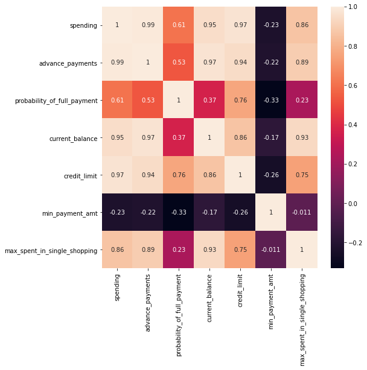

```python
#heat map
cor=df.corr()
cor
plt.figure(figsize=(8,8))
sns.heatmap(cor, annot=True)
```

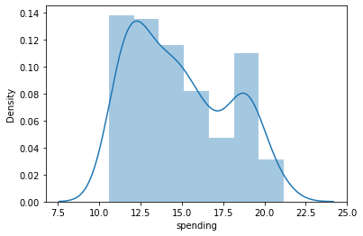

```python
#Bivariate Analysis
sns.distplot(df['spending']);
```

```python
#form the above figure we can conclude that "Spending" is right skewed
```

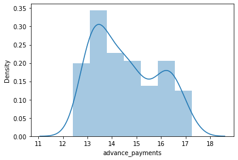

```python
sns.distplot(df['advance_payments']);
```

```python
#form the above figure we can conclude that "advance payment" is right skewed
```

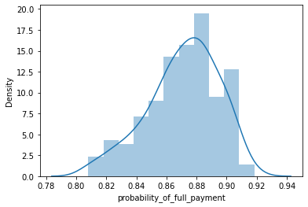

```python
sns.distplot(df['probability_of_full_payment']);
```

```python
#form the above figure we can conclude that "probability_of_full_payment" is left skewed
```

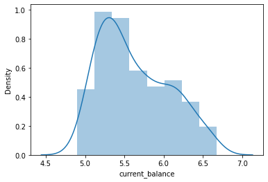

```python
sns.distplot(df['current_balance']);
```

```python
#form the above figure we can conclude that "current balance" is right skewed
```

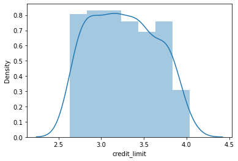

```python
sns.distplot(df['credit_limit']);
```

```python
#form the above figure we can conclude that "credit limit" is Normally distributed
```

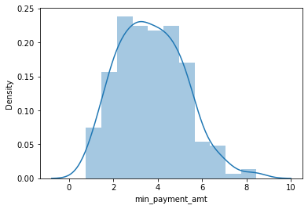

```python
sns.distplot(df['min_payment_amt']);
```

```python
#form the above figure we can conclude that "min payment amount" is right skewed
```

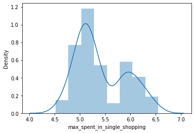

```python
sns.distplot(df['max_spent_in_single_shopping']);
```

```python
#form the above figure we can conclude that "max_spent_in_single_shopping is right skewed
```

# 1.2 Do you think scaling is necessary for clustering in this case? Justify

```python
#scaling
scaled_clust.head()
```

|  | spending | advance_payments | probability_of_full_payment | current_balance | credit_limit | min_payment_amt | max_spent_in_single_shopping |
| --- | --- | --- | --- | --- | --- | --- | --- |
| 0 | 1.754355 | 1.811968 | 0.178230 | 2.367533 | 1.338579 | -0.298806 | 2.328998 |
| 1 | 0.393582 | 0.253840 | 1.501773 | -0.600744 | 0.858236 | -0.242805 | -0.538582 |
| 2 | 1.413300 | 1.428192 | 0.504874 | 1.401485 | 1.317348 | -0.221471 | 1.509107 |
| 3 | -1.384034 | -1.227533 | -2.591878 | -0.793049 | -1.639017 | 0.987884 | -0.454961 |
| 4 | 1.082581 | 0.998364 | 1.196340 | 0.591544 | 1.155464 | -1.088154 | 0.874813 |

Yes, scaling is very important as the model works based on the distance based computations scaling is necessary for unscaled data. Scaling needs to be done as the values of the variables are in different scales. Spending, advance payments are in different values and this may get more weightage. Scaling will have all the values in the relative same range. I have used standard scalar for scaling Below is the snapshot of scaled data.

# 1.3 Apply hierarchical clustering to scaled data. Identify the number of optimum clusters using Dendrogram and briefly describe them

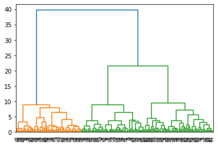

```python
from scipy.cluster.hierarchy import dendrogram, linkage

wardlink = linkage(scaled_clust,method='ward')
dend = dendrogram(wardlink)
```

The above dendrogram indicates all the data points have clustered to different clusters by wards method. To find the optimal number cluster through which we can solve our business objective we use truncate mode = lastp. Wherein we can give last p = 10 according to industry set base value.

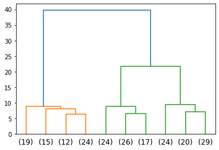

```python
dend = dendrogram(wardlink,
                 truncate_mode='lastp',
                 p = 10,
                 )
```

Now, we can understand all the data points have clustered into 3 clusters. Next to map these clusters to our dataset we can use fclusters Criterion we can give “maxclust”

```python
from scipy.cluster.hierarchy import fcluster
# Set criterion as maxclust,then create 3 clusters, and store the result in another object 'clusters'

clusters = fcluster(wardlink, 3, criterion = 'maxclust')
clusters
```

```
array([1, 3, 1, 2, 1, 2, 2, 3, 1, 2, 1, 3, 2, 1, 3, 2, 3, 2, 3, 2, 2, 2,
       1, 2, 3, 1, 3, 2, 2, 2, 3, 2, 2, 3, 2, 2, 2, 2, 2, 1, 1, 3, 1, 1,
       2, 2, 3, 1, 1, 1, 2, 1, 1, 1, 1, 1, 2, 2, 2, 1, 3, 2, 2, 3, 3, 1,
       1, 3, 1, 2, 3, 2, 1, 1, 2, 1, 3, 2, 1, 3, 3, 3, 3, 1, 2, 3, 3, 1,
       1, 2, 3, 1, 3, 2, 2, 1, 1, 1, 2, 1, 2, 1, 3, 1, 3, 1, 1, 2, 2, 1,
       3, 3, 1, 2, 2, 1, 3, 3, 2, 1, 3, 2, 2, 2, 3, 3, 1, 2, 3, 3, 2, 3,
       3, 1, 2, 1, 1, 2, 1, 3, 3, 3, 2, 2, 3, 2, 1, 2, 3, 2, 3, 2, 3, 3,
       3, 3, 3, 2, 3, 1, 1, 2, 1, 1, 1, 2, 1, 3, 3, 3, 3, 2, 3, 1, 1, 1,
       3, 3, 1, 2, 3, 3, 3, 3, 1, 1, 3, 3, 3, 2, 3, 3, 2, 1, 3, 1, 1, 2,
       1, 2, 3, 1, 3, 2, 1, 3, 1, 3, 1, 3], dtype=int32)
```

```python
df['clusters'] = clusters
df.head(10)
```

|  | spending | advance_payments | probability_of_full_payment | current_balance | credit_limit | min_payment_amt | max_spent_in_single_shopping | clusters |
| --- | --- | --- | --- | --- | --- | --- | --- | --- |
| 0 | 19.94 | 16.92 | 0.8752 | 6.675 | 3.763 | 3.252 | 6.550 | 1 |
| 1 | 15.99 | 14.89 | 0.9064 | 5.363 | 3.582 | 3.336 | 5.144 | 3 |
| 2 | 18.95 | 16.42 | 0.8829 | 6.248 | 3.755 | 3.368 | 6.148 | 1 |
| 3 | 10.83 | 12.96 | 0.8099 | 5.278 | 2.641 | 5.182 | 5.185 | 2 |
| 4 | 17.99 | 15.86 | 0.8992 | 5.890 | 3.694 | 2.068 | 5.837 | 1 |
| 5 | 12.70 | 13.41 | 0.8874 | 5.183 | 3.091 | 8.456 | 5.000 | 2 |
| 6 | 12.02 | 13.33 | 0.8503 | 5.350 | 2.810 | 4.271 | 5.308 | 2 |
| 7 | 13.74 | 14.05 | 0.8744 | 5.482 | 3.114 | 2.932 | 4.825 | 3 |
| 8 | 18.17 | 16.26 | 0.8637 | 6.271 | 3.512 | 2.853 | 6.273 | 1 |
| 9 | 11.23 | 12.88 | 0.8511 | 5.140 | 2.795 | 4.325 | 5.003 | 2 |

# Cluster Frequency

```python
df.clusters.value_counts().sort_index()
```

```
1    70
2    67
3    73
Name: clusters, dtype: int64
```